# R - Assignment Mod 2 Week 2

Michael Womble

1/27/2022

```r
# 1. Answer each question using in words/paragraph.
# 2. DO NOT use comments inside code blocks (like here) to answer anything. Those are for notes between coders/self. They
# will be ignored, and not counted as answers.
# 3. Keep the line/option    knitr::opts_chunk$set(warning = F, results = "hide", message = F)
# You can temporarily turn this on/off and use other option while you are working on the homework if it helps.
# The submitted work should have this option selected instead.
# 4. All charts/graphs/tables should have appropriate captions.
```

# HW - Module 2 week 02

## Q1.

Read in the file with all the baseball players height, weight and age info (BaseballHeightWeight.csv) as a dataframe and save it as baseball. Then display the structure of the dataframe.

```r
baseball<-data.frame(read.csv("BaseballHeightWeight.csv"))
str(baseball)
```

```
## 'data.frame':    1034 obs. of  6 variables:
##  $ Name          : chr  "Adam_Donachie" "Paul_Bako" "Ramon_Hernandez" "Kevin_Millar" ...
##  $ Team          : chr  "BAL" "BAL" "BAL" "BAL" ...
##  $ Position      : chr  "Catcher" "Catcher" "Catcher" "First_Baseman" ...
##  $ Height.inches.: int  74 74 72 72 73 69 69 71 76 71 ...
##  $ Weight.pounds.: int  180 215 210 210 188 176 209 200 231 180 ...
##  $ Age           : num  23 34.7 30.8 35.4 35.7 ...
```

The baseball data is shown to be a data frame with 1034 players listed (observables) and listing 6 variables for each player.

## Q2.

print out the first 5 and the last 3 rows of the dataframe

```r
head(baseball, 5)
```

```
##              Name Team      Position Height.inches. Weight.pounds.  Age
## 1   Adam_Donachie  BAL       Catcher             74            180 23.0
## 2       Paul_Bako  BAL       Catcher             74            215 34.7
## 3 Ramon_Hernandez  BAL       Catcher             72            210 30.8
## 4    Kevin_Millar  BAL First_Baseman             72            210 35.4
## 5     Chris_Gomez  BAL First_Baseman             73            188 35.7
```

```r
tail(baseball, 3)
```

```
##                Name Team       Position Height.inches. Weight.pounds.  Age
## 1032 Chris_Narveson  STL Relief_Pitcher             75            205 25.2
## 1033  Randy_Keisler  STL Relief_Pitcher             75            190 31.0
## 1034    Josh_Kinney  STL Relief_Pitcher             73            195 27.9
```

## Q3.

Change the headers/column names from Weight.pounds. to weight, from Height.inches. to height, and Age to age.

```r
colnames(baseball)[which(names(baseball)=="Weight.pounds.")]<-"weight"
colnames(baseball)[which(names(baseball)=="Height.inches.")]<-"height"
colnames(baseball)[which(names(baseball)=="Age")]<-"age"
```

## Q4.

Print out the first two lines again to see the new column names.

```r
head(baseball, 2)
```

```
##            Name Team Position height weight  age
## 1 Adam_Donachie  BAL  Catcher     74    180 23.0
## 2     Paul_Bako  BAL  Catcher     74    215 34.7
```

## Q5.

Find the statistics (summary) of the heights, weights, and ages of the players. Using complete sentences, give the reader these summary.

```r
summary(baseball)
```

```
##      Name               Team             Position             height
##  Length:1034        Length:1034        Length:1034        Min.   :67.0
##  Class :character   Class :character   Class :character   1st Qu.:72.0
##  Mode  :character   Mode  :character   Mode  :character   Median :74.0
##                                                           Mean   :73.7
##                                                           3rd Qu.:75.0
##                                                           Max.   :83.0
##
##      weight         age
##  Min.   :150   Min.   :20.9
##  1st Qu.:187   1st Qu.:25.4
##  Median :200   Median :27.9
##  Mean   :202   Mean   :28.7
##  3rd Qu.:215   3rd Qu.:31.2
##  Max.   :290   Max.   :48.5
##  NA's   :1
```

The distribution of player heights has a mean equal to 73.7 inches, a median equal to 74 inches. The tallest player is 83 inches tall and the shortest player is 67 inches.

The distribution of player weights has a mean equal to 202 pounds, a median equal to 200 pounds. The heaviest player is 290 pounds and the lightest player is 150 pounds.

The distribution of player ages has a mean equal to 28.7 years, a median equal to 27.9 years. The oldest player is 48.5 years old and the youngest player is 20.9 years old.

## Q6.

You should find an issue with the weight data with an NA value. Use the subset( ) function, select that data point (save as shyboy) and find out who the shy boy was.

```r
shyboy<-subset(baseball,is.na(weight))
shyboy
```

```
##              Name Team         Position height weight  age
## 641 Kirk_Saarloos  CIN Starting_Pitcher     72     NA 27.8
```

The shyboy is Kirk Saarloos.

## Q7.

Remove shyboy from baseball, and then show the number of observations of the cleaned up dataframe baseball.

```r
baseball_clean=baseball[-c(641)]
str(baseball_clean)
```

```
## 'data.frame':    1034 obs. of  6 variables:
##  $ Name    : chr  "Adam_Donachie" "Paul_Bako" "Ramon_Hernandez" "Kevin_Millar" ...
##  $ Team    : chr  "BAL" "BAL" "BAL" "BAL" ...
##  $ Position: chr  "Catcher" "Catcher" "Catcher" "First_Baseman" ...
##  $ height  : int  74 74 72 72 73 69 69 71 76 71 ...
##  $ weight  : int  180 215 210 210 188 176 209 200 231 180 ...
##  $ age     : num  23 34.7 30.8 35.4 35.7 ...
```

## Q8.

Make a quick boxplot of the weight of the players. Use the title( ) function immediately to add a title to the chart. (Try color #0000FF for blue.)

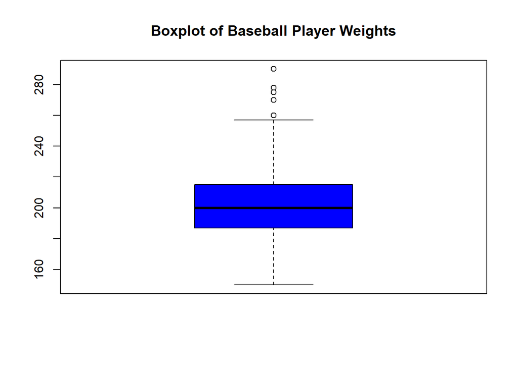

```r
boxplot(baseball_clean$weight, col="Blue")
title("Boxplot of Baseball Player Weights")
```

## Q9.

Make a histogram of the weight of the players. Try color ‘green’ this time. The function understands the word ‘green’ just fine. Give it a better title than the default. Does the distribution looks normal?

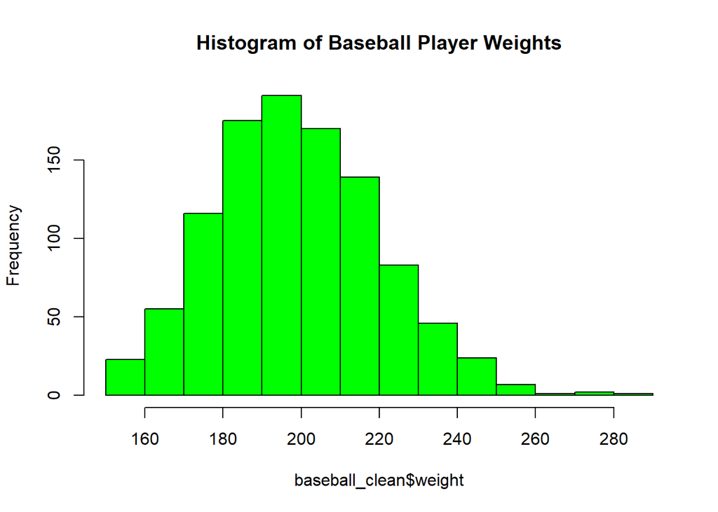

```r
hist(baseball_clean$weight, main='Histogram of Baseball Player Weights', col='Green')
```

## Q10.

Use ggplot, make a plot with weights vs heights of the players, color by Teams. Give it an appropriate title.

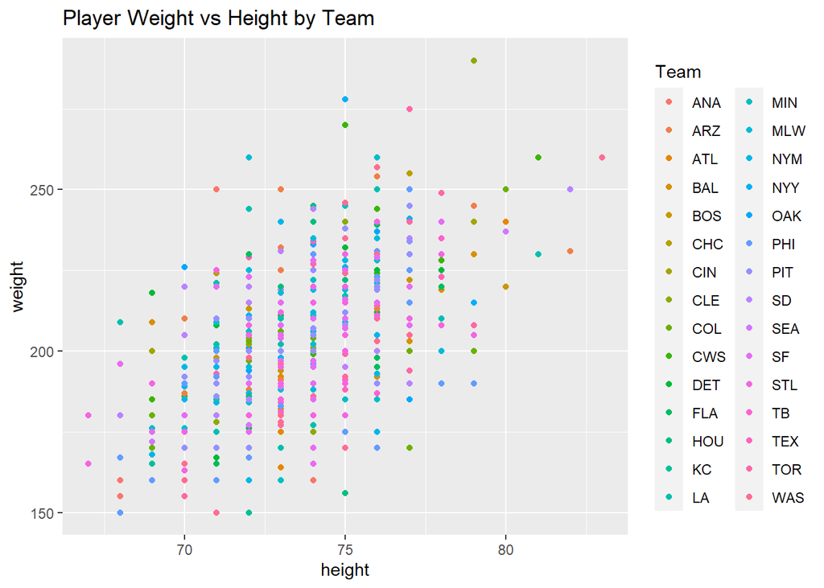

```r
library(ggplot2)
ggplot(data=baseball_clean, mapping=aes(x=height, y=weight))+geom_point(aes(color=Team))+labs(title='Player Weight vs Height by Team')
```

## Q11.

Make a plot with weights vs heights of the players, color by age

[figure not shown]

```r
ggplot(data=baseball_clean, mapping=aes(x=height, y=weight))+geom_point(aes(color=age))+labs(title='Player Weight vs Height by Team')
```

## Q12.

Obtain a subset of the data with only Team Washington. Using complete sentences, give the number of players in Team Washington.

```r
team_washington<-subset(baseball_clean, Team=='WAS')
str(team_washington)
```

```
## 'data.frame':    36 obs. of  6 variables:
##  $ Name    : chr  "Brian_Schneider" "Jesus_Flores" "Larry_Broadway" "Nick_Johnson" ...
##  $ Team    : chr  "WAS" "WAS" "WAS" "WAS" ...
##  $ Position: chr  "Catcher" "Catcher" "First_Baseman" "First_Baseman" ...
##  $ height  : int  73 73 76 75 70 73 72 73 75 74 ...
##  $ weight  : int  196 180 230 224 160 178 205 185 210 180 ...
##  $ age     : num  30.3 22.3 26.2 28.4 27.6 ...
```

There are 36 players on Washington

## Q13.

Obtain another subset with Team Washington and only players older than 28. How many are there in this veteran group?

```r
veteran_washington<-subset(team_washington, age>28)
str(veteran_washington)
```

```
## 'data.frame':    14 obs. of  6 variables:
##  $ Name    : chr  "Brian_Schneider" "Nick_Johnson" "Cristian_Guzman" "Ryan_Church" ...
##  $ Team    : chr  "WAS" "WAS" "WAS" "WAS" ...
##  $ Position: chr  "Catcher" "First_Baseman" "Shortstop" "Outfielder" ...
##  $ height  : int  73 75 72 73 76 73 72 77 75 71 ...
##  $ weight  : int  196 224 205 190 257 190 200 208 210 150 ...
##  $ age     : num  30.3 28.4 28.9 28.4 28.2 ...
```

There are 14 players over the age of 28 on Washington.